# Data Collection and Analysis

Bryan Persaud

5/11/2021

```r
# Libraries
library(tidyverse)
```

Two datasets were collected from Kaggle. The first one shows different streaming services, Netflix, Hulu, Amazon Prime Video, and Disney+. The second one shows the number of subscribers for Netflix.

# Data Exploration

Let’s explore these datasets a little to see what they contain.

```r
shows <- read.csv("~/DATA 698/Data Collection and Analysis/Datasets/tv_shows.csv")
summary(shows)
```

```
##        X           Title                Year          Age
##  Min.   :   0   Length:5611        Min.   :1901   Length:5611
##  1st Qu.:1402   Class :character   1st Qu.:2010   Class :character
##  Median :2805   Mode  :character   Median :2015   Mode  :character
##  Mean   :2805                      Mean   :2011
##  3rd Qu.:4208                      3rd Qu.:2017
##  Max.   :5610                      Max.   :2020
##
##       IMDb       Rotten.Tomatoes       Netflix            Hulu
##  Min.   :1.000   Length:5611        Min.   :0.0000   Min.   :0.0000
##  1st Qu.:6.600   Class :character   1st Qu.:0.0000   1st Qu.:0.0000
##  Median :7.300   Mode  :character   Median :0.0000   Median :0.0000
##  Mean   :7.113                      Mean   :0.3441   Mean   :0.3126
##  3rd Qu.:7.900                      3rd Qu.:1.0000   3rd Qu.:1.0000
##  Max.   :9.600                      Max.   :1.0000   Max.   :1.0000
##  NA's   :1161
##   Prime.Video        Disney.             type
##  Min.   :0.0000   Min.   :0.00000   Min.   :1
##  1st Qu.:0.0000   1st Qu.:0.00000   1st Qu.:1
##  Median :0.0000   Median :0.00000   Median :1
##  Mean   :0.3821   Mean   :0.03208   Mean   :1
##  3rd Qu.:1.0000   3rd Qu.:0.00000   3rd Qu.:1
##  Max.   :1.0000   Max.   :1.00000   Max.   :1
##
```

```r
head(shows, 50)
```

```
##     X                            Title Year Age IMDb Rotten.Tomatoes Netflix
## 1   0                     Breaking Bad 2008 18+  9.5             96%       1
## 2   1                  Stranger Things 2016 16+  8.8             93%       1
## 3   2                      Money Heist 2017 18+  8.4             91%       1
## 4   3                         Sherlock 2010 16+  9.1             78%       1
## 5   4                 Better Call Saul 2015 18+  8.7             97%       1
## 6   5                       The Office 2005 16+  8.9             81%       1
## 7   6                     Black Mirror 2011 18+  8.8             83%       1
## 8   7                     Supernatural 2005 16+  8.4             93%       1
## 9   8                   Peaky Blinders 2013 18+  8.8             92%       1
## 10  9       Avatar: The Last Airbender 2005  7+  9.2            100%       1
## 11 10                 The Walking Dead 2010 18+  8.2             81%       1
## 12 11                             Dark 2017 16+  8.7             94%       1
## 13 12                            Ozark 2017 18+  8.4             81%       1
## 14 13                  Attack on Titan 2013 16+  8.8             94%       1
```

[output cut: 87 more lines]

The first dataset has each observation as a different TV show, there are 5611 different observation. Each of them is shown the year the show came out, the IMDb and Rotten Tomatoes rating, and whether the show is in the specified streaming service. A value of 1 means that the show is included in the streaming service and a value of 0 means that the show is not in the streaming service.

```r
Netflix_subs <- read.csv("~/DATA 698/Data Collection and Analysis/Datasets/DataNetflixSubscriber2020_V2.csv")
head(Netflix_subs, 40)
```

```
##                               Area     Years Subscribers
## 1         United States and Canada Q1 - 2018    60909000
## 2  Europe,  Middle East and Africa Q1 - 2018    29339000
## 3                    Latin America Q1 - 2018    21260000
## 4                     Asia-Pacific Q1 - 2018     7394000
## 5         United States and Canada Q2 - 2018    61870000
## 6  Europe,  Middle East and Africa Q2 - 2018    31317000
## 7                    Latin America Q2 - 2018    22795000
## 8                     Asia-Pacific Q2 - 2018     8372000
## 9         United States and Canada Q3 - 2018    63010000
## 10 Europe,  Middle East and Africa Q3 - 2018    33836000
## 11                   Latin America Q3 - 2018    24115000
## 12                    Asia-Pacific Q3 - 2018     9461000
## 13        United States and Canada Q4 - 2018    64757000
## 14 Europe,  Middle East and Africa Q4 - 2018    37818000
```

[output cut: 26 more lines]

The second dataset has each observation as a certain area for each quarter from the year 2018 to 2020. There are 40 observations showing 4 quarters for the year 2018 and 2019, and the first two quarters for the year 2020. The number of subscribers are shown for each area by the quarter of that year.

# Data Analysis

```r
Netflix <- shows %>%
  select(Title, Year, Age, IMDb, Rotten.Tomatoes, Netflix) %>%
  filter(Netflix == 1) %>%
  group_by(Title)
Netflix
```

```
## # A tibble: 1,931 x 6
## # Groups:   Title [1,925]
##    Title                       Year Age    IMDb Rotten.Tomatoes Netflix
##    <chr>                      <int> <chr> <dbl> <chr>             <int>
##  1 Breaking Bad                2008 18+     9.5 96%                   1
##  2 Stranger Things             2016 16+     8.8 93%                   1
##  3 Money Heist                 2017 18+     8.4 91%                   1
##  4 Sherlock                    2010 16+     9.1 78%                   1
##  5 Better Call Saul            2015 18+     8.7 97%                   1
##  6 The Office                  2005 16+     8.9 81%                   1
##  7 Black Mirror                2011 18+     8.8 83%                   1
##  8 Supernatural                2005 16+     8.4 93%                   1
##  9 Peaky Blinders              2013 18+     8.8 92%                   1
## 10 Avatar: The Last Airbender  2005 7+      9.2 100%                  1
## # ... with 1,921 more rows
```

```r
Hulu <- shows %>%
  select(Title, Year, Age, IMDb, Rotten.Tomatoes, Hulu) %>%
  filter(Hulu == 1) %>%
  group_by(Title)
Hulu
```

```
## # A tibble: 1,754 x 6
## # Groups:   Title [1,739]
##    Title                             Year Age    IMDb Rotten.Tomatoes  Hulu
##    <chr>                            <int> <chr> <dbl> <chr>           <int>
##  1 Attack on Titan                   2013 16+     8.8 94%                 1
##  2 Fullmetal Alchemist: Brotherhood  2009 18+     9.1 100%                1
##  3 Community                         2009 7+      8.5 88%                 1
##  4 Parks and Recreation              2009 16+     8.6 93%                 1
##  5 Twin Peaks                        1990 18+     8.8 89%                 1
##  6 One-Punch Man                     2015 16+     8.8 100%                1
##  7 The Good Place                    2016 16+     8.2 97%                 1
##  8 Grey's Anatomy                    2005 16+     7.6 83%                 1
##  9 Arrested Development              2003 16+     8.7 75%                 1
## 10 How to Get Away with Murder       2014 16+     8.1 88%                 1
## # ... with 1,744 more rows
```

```r
Prime_video <- shows %>%
  select(Title, Year, Age, IMDb, Rotten.Tomatoes, Prime.Video) %>%
  filter(Prime.Video == 1) %>%
  group_by(Title)
Prime_video
```

```
## # A tibble: 2,144 x 6
## # Groups:   Title [2,138]
##    Title                            Year Age    IMDb Rotten.Tomatoes Prime.Video
##    <chr>                           <int> <chr> <dbl> <chr>                 <int>
##  1 Parks and Recreation             2009 16+     8.6 "93%"                     1
##  2 Star Trek: The Next Generation   1987 7+      8.6 "89%"                     1
##  3 The Good Wife                    2009 16+     8.3 "94%"                     1
##  4 Schitt's Creek                   2015 16+     8.4 "50%"                     1
##  5 Burn Notice                      2007 7+      7.9 "88%"                     1
##  6 American Horror Story            2011 18+     8   ""                        1
##  7 Star Trek                        1966 7+      8.3 "80%"                     1
##  8 Mushi-Shi                        2005 16+     8.5 "100%"                    1
##  9 Star Trek: Deep Space Nine       1993 7+      7.9 "90%"                     1
## 10 Law & Order: Special Victims U~  1999 16+     8   ""                        1
## # ... with 2,134 more rows
```

```r
Disney_plus <- shows %>%
  select(Title, Year, Age, IMDb, Rotten.Tomatoes, Disney.) %>%
  filter(Disney. == 1) %>%
  group_by(Title)
Disney_plus
```

```
## # A tibble: 180 x 6
## # Groups:   Title [179]
##    Title                           Year Age    IMDb Rotten.Tomatoes Disney.
##    <chr>                          <int> <chr> <dbl> <chr>             <int>
##  1 Lab Rats                        2012 7+      6.6 ""                    1
##  2 America's Funniest Home Videos  1989 7+      6.2 ""                    1
##  3 Brain Games                     2011 7+      8.3 ""                    1
##  4 Jessie                          2011 all     5.9 ""                    1
##  5 PJ Masks                        2015 all     5.6 ""                    1
##  6 Best Friends Whenever           2015 all     5.5 ""                    1
##  7 The Simpsons                    1989 7+      8.7 "85%"                 1
##  8 Gravity Falls                   2012 7+      8.9 "100%"                1
##  9 Marvel's Runaways               2017 16+     7   "87%"                 1
## 10 Star vs. the Forces of Evil     2015 7+      8   ""                    1
## # ... with 170 more rows
```

From sorting the data we see what shows are available for each streaming services, Netflix, Hulu, Prime video, and Disney+. We see that Prime Video contains more shows than the other streaming services while Disney+ contains the least amount. From the data we can see that Netflix contains more shows that have higher ratings. This is based on the IMDb and Rotten Tomatoes scores.

[figure not shown]

```r
ggplot(Netflix, aes(x = Title, y = IMDb)) + geom_point()
```

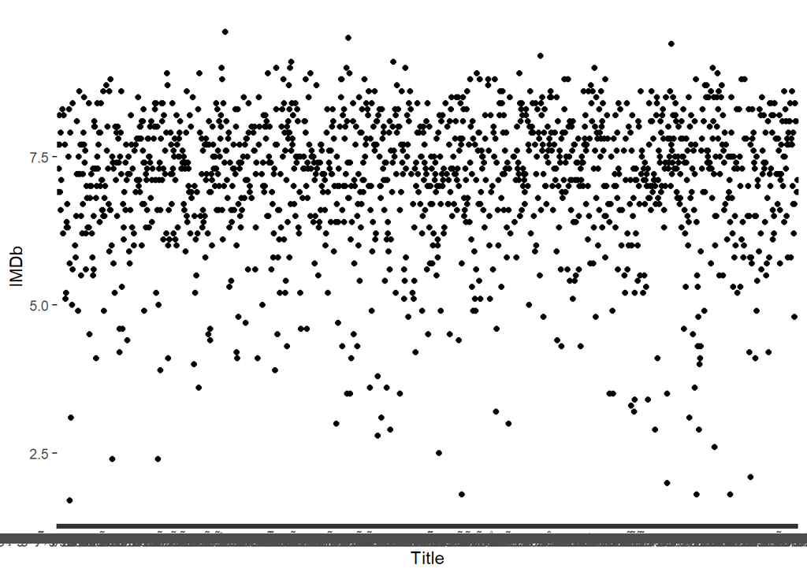

```r
ggplot(Hulu, aes(x = Title, y = IMDb)) + geom_point()
```

[figure not shown]

```r
ggplot(Prime_video, aes(x = Title, y = IMDb)) + geom_point()
```

[figure not shown]

```r
ggplot(Disney_plus, aes(x = Title, y = IMDb)) + geom_point()
```

Since Netflix and Amazon Prime Video seem to be two of the biggest streaming services let us look into the number of people who have subscribed to these services over the years. This will give us an insight on whether people are using these services and how much they have grown. I will be using data I found on Netflix subscriptions to show this.